# Project Machine Learning: AllLife Bank Data Analysis by Gabriel Hinojos

## Decision Tree (Post-pruning)

```python
# Create a decision tree model instance
clf = DecisionTreeClassifier(random_state=1)

# Compute the cost complexity pruning path from the training data
path = clf.cost_complexity_pruning_path(X_train, y_train)

# Extract the array of effective alphas
ccp_alphas = abs(path.ccp_alphas)

# Extract the array of total impurities
impurities = path.impurities
```

```python
pd.DataFrame(path)
```

|  | ccp_alphas | impurities |
| --- | --- | --- |
| 0 | 0.000000 | 0.000000 |
| 1 | 0.000186 | 0.001114 |
| 2 | 0.000214 | 0.001542 |
| 3 | 0.000242 | 0.002750 |
| 4 | 0.000250 | 0.003250 |
| 5 | 0.000268 | 0.004324 |
| 6 | 0.000272 | 0.004868 |
| 7 | 0.000276 | 0.005420 |
| 8 | 0.000381 | 0.005801 |
| 9 | 0.000527 | 0.006329 |
| 10 | 0.000625 | 0.006954 |
| 11 | 0.000700 | 0.007654 |
| 12 | 0.000769 | 0.010731 |
| 13 | 0.000882 | 0.014260 |
| 14 | 0.000889 | 0.015149 |
| 15 | 0.001026 | 0.017200 |
| 16 | 0.001305 | 0.018505 |
| 17 | 0.001647 | 0.020153 |
| 18 | 0.002333 | 0.022486 |
| 19 | 0.002407 | 0.024893 |
| 20 | 0.003294 | 0.028187 |
| 21 | 0.006473 | 0.034659 |
| 22 | 0.025146 | 0.084951 |
| 23 | 0.039216 | 0.124167 |
| 24 | 0.047088 | 0.171255 |

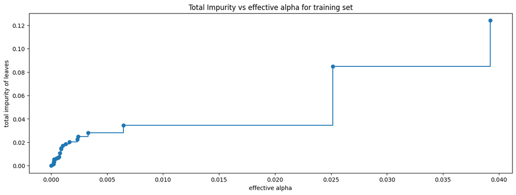

```python
# Plot the total impurities versus effective alphas using markers at each data point and connecting them with steps
fig, ax = plt.subplots(figsize=(15, 5))
ax.plot(ccp_alphas[:-1], impurities[:-1], marker="o", drawstyle="steps-post")

# Set the x-axis label, y-axis label, and plot title
ax.set_xlabel("effective alpha")
ax.set_ylabel("total impurity of leaves")
ax.set_title("Total Impurity vs effective alpha for training set")
plt.show()
```

### Train the decision tree with effective alphas

```python
# Inititialize an empty list to store decision tree classifiers
# Then loop through ccp_alpha value extracted from cost complexity pruning path
clfs = []
for ccp_alpha in ccp_alphas:
    # create DecisionTreeClassifier classifier with random state = 1 and blanaced class weight
    clf = DecisionTreeClassifier(random_state=1, ccp_alpha=ccp_alpha, class_weight="balanced")
    # fit classfier to the training data
    clf.fit(X_train, y_train)
    # append the classifier that has been trained to the list
    clfs.append(clf)
print(
    "Number of nodes in the last tree is: {} with ccp_alpha: {}".format(
        clfs[-1].tree_.node_count, ccp_alphas[-1]
    )
)
```

```
Number of nodes in the last tree is: 3 with ccp_alpha: 0.04708834100596766
```

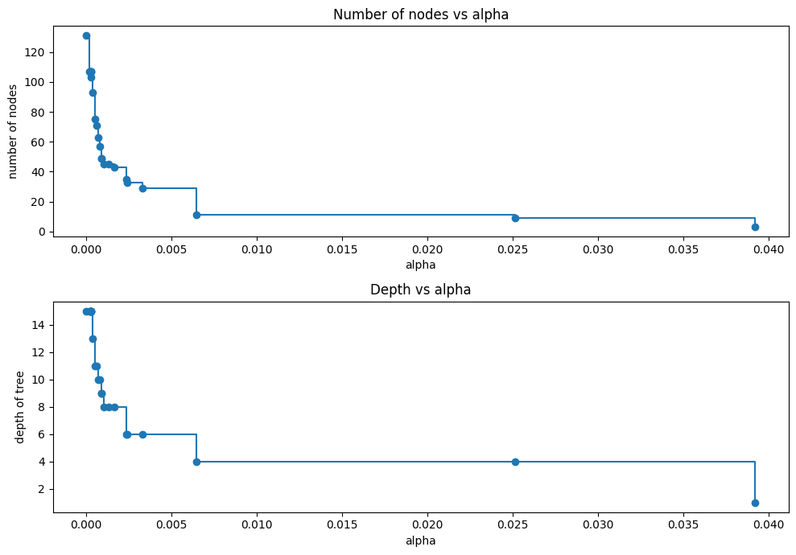

```python
# Remove the last classifier and corresponding ccp_alpha value from the lists
# Then extract the following: number of nodes for each classifier, the maximum
# depth of each classifier. Then plot the results.
clfs = clfs[:-1]
ccp_alphas = ccp_alphas[:-1]

node_counts = [clf.tree_.node_count for clf in clfs]
depth = [clf.tree_.max_depth for clf in clfs]
fig, ax = plt.subplots(2, 1, figsize=(10, 7))
ax[0].plot(ccp_alphas, node_counts, marker="o", drawstyle="steps-post")
ax[0].set_xlabel("alpha")
ax[0].set_ylabel("number of nodes")
ax[0].set_title("Number of nodes vs alpha")
ax[1].plot(ccp_alphas, depth, marker="o", drawstyle="steps-post")
ax[1].set_xlabel("alpha")
ax[1].set_ylabel("depth of tree")
ax[1].set_title("Depth vs alpha")
fig.tight_layout()
```

### Calculate the Recall scores for training and test sets

```python
# Initialize an empty list to store Recall scores for training set for each decision tree classifier
# Then loop through each decision tree in clfs, calculate the recall score for training, and append score

recall_train = []
for clf in clfs:
    pred_train = clf.predict(X_train)
    values_train = recall_score(y_train, pred_train)
    recall_train.append(values_train)
```

```python
# Initialize an empty list to store Recall scores for test set for each decision tree classifier
# Then loop through each decision tree in clfs, calculate the recall score for testing, and append score
recall_test = []
for clf in clfs:
    pred_test = clf.predict(X_test)
    values_test = recall_score(y_test, pred_test)
    recall_test.append(values_test)
```

### Create the model highest Recall score

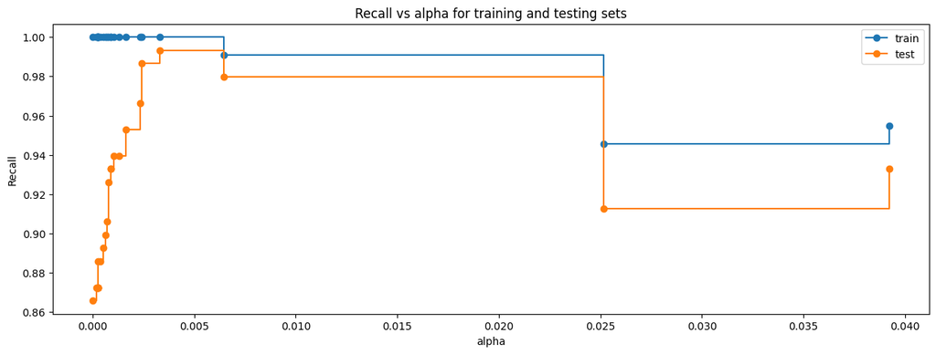

```python
# plot the training and testing Recall scores
fig, ax = plt.subplots(figsize=(15, 5))
ax.set_xlabel("alpha")
ax.set_ylabel("Recall")
ax.set_title("Recall vs alpha for training and testing sets")
ax.plot(ccp_alphas, recall_train, marker="o", label="train", drawstyle="steps-post")
ax.plot(ccp_alphas, recall_test, marker="o", label="test", drawstyle="steps-post")
ax.legend()
plt.show()
```

```python
# Create the model where we get highest train and test recall score
index_best_model = np.argmax(recall_test)
best_model = clfs[index_best_model]
print(best_model)
```

```
DecisionTreeClassifier(ccp_alpha=np.float64(0.003293801935470502),
                       class_weight='balanced', random_state=1)
```

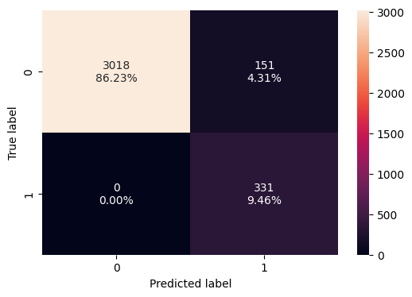

```python
# Create confusion matrix for training data
model3 = best_model
plot_confusion_matrix(model3, X_train, y_train)
```

```python
# Run performance model scores for training data
decision_tree_post_perf_train = model_performance_classification(
    model3, X_train, y_train
)
decision_tree_post_perf_train
```

|  | Accuracy | Recall | Precision | F1 |
| --- | --- | --- | --- | --- |
| 0 | 0.956857 | 1.0 | 0.686722 | 0.814268 |

### Model Evaluation

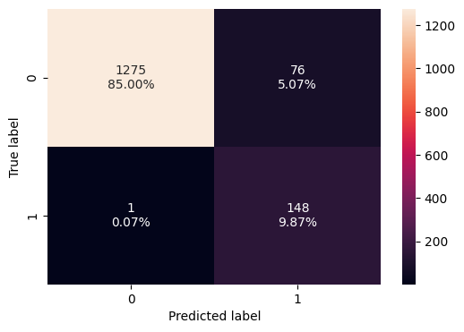

```python
# Create confusion matrix for tets data
plot_confusion_matrix(model3, X_test, y_test)
```

```python
# Run performance model scores for test data
decision_tree_post_perf_test = model_performance_classification(
    model3, X_test, y_test
)
decision_tree_post_perf_test
```

|  | Accuracy | Recall | Precision | F1 |
| --- | --- | --- | --- | --- |
| 0 | 0.948667 | 0.993289 | 0.660714 | 0.793566 |

Observation: The test and training scores are very close to each other which indicates a generalized performance

### Visualizing the Decision Tree

```python
# list of feature names in X_train
feature_names = list(X_train.columns)
```

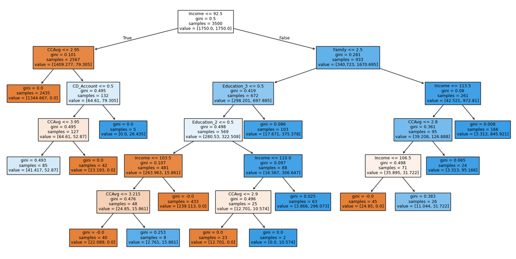

```python
# Plot the decision tree
plt.figure(figsize=(20, 10))

out = tree.plot_tree(
    model3,
    feature_names=feature_names,
    filled=True,
    fontsize=9,
    node_ids=False,
    class_names=None,
)
for o in out:
    arrow = o.arrow_patch
    if arrow is not None:
        arrow.set_edgecolor("black")
        arrow.set_linewidth(1)
plt.show()
plt.show()
```

Observations: The model is far less complex than the default model

```python
# print text report with the rules of the decision tree

print(tree.export_text(model3, feature_names=feature_names, show_weights=True))
```

```
|--- Income <= 92.50
|   |--- CCAvg <= 2.95
|   |   |--- weights: [1344.67, 0.00] class: 0
|   |--- CCAvg >  2.95
|   |   |--- CD_Account <= 0.50
|   |   |   |--- CCAvg <= 3.95
|   |   |   |   |--- weights: [41.42, 52.87] class: 1
|   |   |   |--- CCAvg >  3.95
|   |   |   |   |--- weights: [23.19, 0.00] class: 0
|   |   |--- CD_Account >  0.50
|   |   |   |--- weights: [0.00, 26.44] class: 1
|--- Income >  92.50
|   |--- Family <= 2.50
|   |   |--- Education_3 <= 0.50
|   |   |   |--- Education_2 <= 0.50
|   |   |   |   |--- Income <= 103.50
|   |   |   |   |   |--- CCAvg <= 3.21
|   |   |   |   |   |   |--- weights: [22.09, 0.00] class: 0
|   |   |   |   |   |--- CCAvg >  3.21
|   |   |   |   |   |   |--- weights: [2.76, 15.86] class: 1
|   |   |   |   |--- Income >  103.50
|   |   |   |   |   |--- weights: [239.11, 0.00] class: 0
|   |   |   |--- Education_2 >  0.50
|   |   |   |   |--- Income <= 110.00
|   |   |   |   |   |--- CCAvg <= 2.90
|   |   |   |   |   |   |--- weights: [12.70, 0.00] class: 0
|   |   |   |   |   |--- CCAvg >  2.90
|   |   |   |   |   |   |--- weights: [0.00, 10.57] class: 1
|   |   |   |   |--- Income >  110.00
|   |   |   |   |   |--- weights: [3.87, 296.07] class: 1
|   |   |--- Education_3 >  0.50
|   |   |   |--- weights: [17.67, 375.38] class: 1
|   |--- Family >  2.50
|   |   |--- Income <= 113.50
|   |   |   |--- CCAvg <= 2.80
|   |   |   |   |--- Income <= 106.50
|   |   |   |   |   |--- weights: [24.85, 0.00] class: 0
|   |   |   |   |--- Income >  106.50
|   |   |   |   |   |--- weights: [11.04, 31.72] class: 1
|   |   |   |--- CCAvg >  2.80
|   |   |   |   |--- weights: [3.31, 95.17] class: 1
|   |   |--- Income >  113.50
|   |   |   |--- weights: [3.31, 845.92] class: 1
```

### Feature Importances

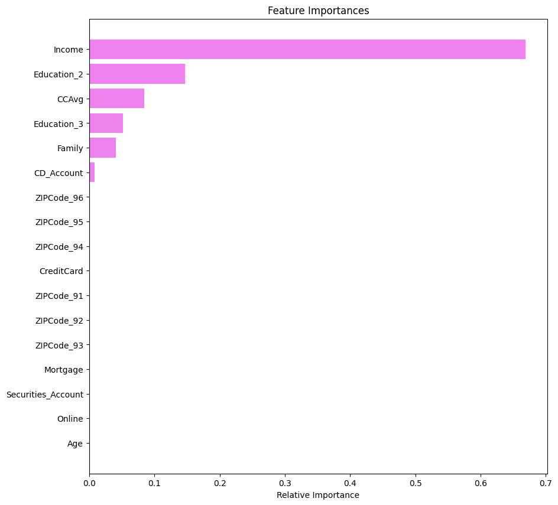

```python
# Print the top features by importance
importances = model3.feature_importances_
indices = np.argsort(importances)

plt.figure(figsize=(10, 10))
plt.title("Feature Importances")
plt.barh(range(len(indices)), importances[indices], color="violet", align="center")
plt.yticks(range(len(indices)), [feature_names[i] for i in indices])
plt.xlabel("Relative Importance")
plt.show()
```

Observations: The top three features for this model are Income, Graduate Education, and CCAvg (Average spending of credit cards per month)

# **Model Performance Comparison and Final Model Selection**

```python
# training performance comparison

models_train_comp_df = pd.concat(
    [
        decision_tree_default_perf_train.T,
        decision_tree_tune_perf_train.T,
        decision_tree_post_perf_train.T,
    ],
    axis=1,
)
models_train_comp_df.columns = [
    "Decision Tree (default)",
    "Decision Tree (Pre-Pruning)",
    "Decision Tree (Post-Pruning)",
]
print("Training performance comparison:")
models_train_comp_df
```

```
Training performance comparison:
```

|  | Decision Tree (default) | Decision Tree (Pre-Pruning) | Decision Tree (Post-Pruning) |
| --- | --- | --- | --- |
| Accuracy | 1.0 | 0.790286 | 0.956857 |
| Recall | 1.0 | 1.000000 | 1.000000 |
| Precision | 1.0 | 0.310798 | 0.686722 |
| F1 | 1.0 | 0.474212 | 0.814268 |

```python
# test performance comparison

models_train_comp_df = pd.concat(
    [
        decision_tree_default_perf_test.T,
        decision_tree_tune_perf_test.T,
        decision_tree_post_perf_test.T,
    ],
    axis=1,
)
models_train_comp_df.columns = [
    "Decision Tree (default)",
    "Decision Tree (Pre-Pruning)",
    "Decision Tree (Post-Pruning)",
]
print("Test set performance comparison:")
models_train_comp_df
```

```
Test set performance comparison:
```

|  | Decision Tree (default) | Decision Tree (Pre-Pruning) | Decision Tree (Post-Pruning) |
| --- | --- | --- | --- |
| Accuracy | 0.986000 | 0.779333 | 0.948667 |
| Recall | 0.932886 | 1.000000 | 0.993289 |
| Precision | 0.926667 | 0.310417 | 0.660714 |
| F1 | 0.929766 | 0.473768 | 0.793566 |

Obervations:

- Decision tree with pre-pruning has low precision and F1 score which means the model is predicting a lot of false positives.
- Decision tree with post-pruning is generalizing well for training and test data sets.
- The post-pruning tree is not as complex as the default model and is easier to read.

# **Actionable Insights and Business Recommendations**

- Annual income of the customer, education level, and average spending on credit cards per month are the most important variables in determing personal loan offers.
- There was a high number of customers with higher incomes who did not accept the personal offer so they could be a target audience.
- Another target audience would be customers with some of the highest credit card averages who did not accept personal loan. Business could look into balance transfers from those higher interest credit cards.
- Some other observations that business may consider: more offers to families of 3 or 4 as they had higher percentages of acceptance, cusomers who have credit cards with other banks, and online users should be analyzed more as there could be additional opportunities.
- Business may want to consider review of further analysis on Zip Codes starting with 91xxx, 93xxx, 96xxx as there was a low amount of loan offers with customers in those Zip Codes.